# SE & LIONNESS - Dataset 2g 100/50

In this script, we will be testing how well SE does at recovering individual networks with LIONESS using Dataset 2g - 100 subjects, 50 taxa.

# 1. Load Library

Packages required to run the script

```r
library(tidyverse)
library(SpiecEasi)
library(here)
library(lme4)
library(Matrix)
library(tscount)
library(patchwork)
library(MASS)
library(matrixcalc)
library(gridExtra)
library(devtools)
library(miaSim)
library(reshape2)
library(ggpubr)
library(broom)
library(ggnewscale)
library(coin)
```

# 2. Data Prep

Read in the data

```r
# Read in the raw data
original_data <- read.csv(here("Data", "GLV_SimData", "Dataset_2g",
                               "SE_100sbj50taxa.csv"))
original_data <- original_data %>% column_to_rownames("X")
counts_data <- original_data

# Cor
original_cor <- read.csv(here("Data", "GLV_SimData", "Dataset_2g",
                               "Cor_100sbj50taxa.csv"))
```

Store the overall count table in a list that will be used downstream

```r
Dataset2g_Res <- list()
Dataset2g_Res$Counts <- counts_data
Dataset2g_Res$Cor <- original_cor
```

# 3. Individual changes

Here we will run SE and Lionness for all the data. Then ID which edge is the strongest in the overall SE network, and change those taxa in one individuals counts. We will then go back and run their samples through lionness and see if it can detect the change

## 3.1 - Group Network

Run SE to get a network for all the data

```r
set.seed(12345)

# Set seed
pseed <- list(rep.num=50, seed=10010)

# Run the SpiecEasi function
net_data <- spiec.easi(
    data.matrix(counts_data),
    method = "glasso",
    sel.criterion = "bstars",
    lambda.min.ratio = 0.01,
    nlambda = 200,
    pulsar.select = TRUE,
    pulsar.params = pseed,
    icov.select = "pulsar.select",
    icov.select.params = "pulsar.params",
    lambda.log = TRUE
  )
```

```
Applying data transformations...
Selecting model with pulsar using bstars...
Fitting final estimate with glasso...
done
```

```r
# Store the results in Dataset1_Res
Dataset2g_Res$SpeicEasi_Time <- net_data
```

## 3.2 - Unaltered Ind Networks

Run LIONESS to get the individual networks of the unaltered data

```r
# Prep the data
################################################
# List to store individual networks
Ind_Nets_unaltered <- list()

# Overall network
net_all <- as.matrix(SpiecEasi::getOptCov(Dataset2g_Res[["SpeicEasi_Time"]]))


# Individualized Networks
################################################
# Set seed
set.seed(12345)
pseed <- list(rep.num=50, seed=10010)

# Loop
for (j in 1:nrow(counts_data)) {
      samplename <- rownames(counts_data[j, ])
      nsamples <- nrow(counts_data)
      net_single <- spiec.easi(data.matrix(counts_data[-j,]),
                                method = "glasso",
                                sel.criterion = "bstars",
                                lambda.min.ratio = 0.01,
                                nlambda = 200,
                                pulsar.select = TRUE,
                                pulsar.params = pseed,
                                icov.select = "pulsar.select",
                                icov.select.params = "pulsar.params",
                                lambda.log = TRUE)
      net_single_cov <- as.matrix(getOptCov(net_single))
      net_name <- samplename
      Ind_Nets_unaltered[[net_name]] <- nsamples * (net_all -
                                                       net_single_cov) + net_single_cov
      colnames(Ind_Nets_unaltered[[net_name]]) <- rownames(Ind_Nets_unaltered[[net_name]]) <- colnames(counts_data)
    }
```

[output not shown]

[output cut: 345 more lines]

[output not shown]

```r
# Store the results
Dataset2g_Res$Ind_Nets_unaltered <- Ind_Nets_unaltered
```

```r
saveRDS(Dataset2g_Res, here("Dataset2g_Res100sbj.rds"))
Dataset2g_Res <- readRDS(here("Dataset2g_Res100sbj.rds"))
```

## 3.3 - Find Edge

Pick up a strong edge

```r
# Extract the Covariance Matrix
net_single_cov <- as.matrix(getOptCov(Dataset2g_Res$SpeicEasi_Time))

# Set Diagnols to 0
diagonal_indices <- 1:nrow(net_single_cov)
net_single_cov[cbind(diagonal_indices, diagonal_indices)] <- 0

# Add species name
colnames(net_single_cov) <- rownames(net_single_cov) <- colnames(counts_data)

# Find the max value
max(net_single_cov, na.rm = TRUE)
```

```
[1] 0.6902405
```

```r
which(net_single_cov == max(net_single_cov, na.rm = TRUE), arr.ind = TRUE)
```

```
     row col
sp28  28  22
sp22  22  28
```

## 3.4 - Change Values

Based on these, set species 28 to 0 in subject one

```r
counts_altered <- counts_data
counts_altered["Sbj1_Time2", 28] <- 0
```

## 3.5 - Individual Networks

Get the overall network first

```r
set.seed(12345)

# Set seed
pseed <- list(rep.num=50, seed=10010)

# Run the SpiecEasi function
net_data <- spiec.easi(
    data.matrix(counts_altered),
    method = "glasso",
    sel.criterion = "bstars",
    lambda.min.ratio = 0.01,
    nlambda = 200,
    pulsar.select = TRUE,
    pulsar.params = pseed,
    icov.select = "pulsar.select",
    icov.select.params = "pulsar.params",
    lambda.log = TRUE
  )
```

```
Applying data transformations...
Selecting model with pulsar using bstars...
Fitting final estimate with glasso...
done
```

```r
# Store the results in Dataset1_Res
Dataset2g_Res$SpeicEasi_Time_alt <- net_data
```

Run LIONESS to get the individual networks

```r
# Prep the data
################################################
# List to store individual networks
Ind_Nets_alt <- list()

# Combined Network
net_all <- as.matrix(SpiecEasi::getOptCov(Dataset2g_Res[["SpeicEasi_Time_alt"]]))


# Individualized Networks
################################################
# Set seed
set.seed(12345)
pseed <- list(rep.num=50, seed=10010)

# Loop
for (j in 1:nrow(counts_altered)) {
      samplename <- rownames(counts_altered[j, ])
      nsamples <- nrow(counts_altered)
      net_single <- spiec.easi(data.matrix(counts_altered[-j,]),
                                method = "glasso",
                                sel.criterion = "bstars",
                                lambda.min.ratio = 0.01,
                                nlambda = 200,
                                pulsar.select = TRUE,
                                pulsar.params = pseed,
                                icov.select = "pulsar.select",
                                icov.select.params = "pulsar.params",
                                lambda.log = TRUE)
      net_single_cov <- as.matrix(getOptCov(net_single))
      net_name <- samplename
      Ind_Nets_alt[[net_name]] <- nsamples * (net_all -
                                                       net_single_cov) + net_single_cov
      colnames(Ind_Nets_alt[[net_name]]) <- rownames(Ind_Nets_alt[[net_name]]) <- colnames(counts_altered)
    }
```

[output not shown]

[output cut: 345 more lines]

[output not shown]

```r
# Store the results
Dataset2g_Res$Ind_Nets_alt <- Ind_Nets_alt
```

## 3.6 - Check Recovery

## 3.6.1 Unaltered Edges

```r
# Create an empty edge list
##########################################
Ind_Edge_Unalt_Table <- list()

# loop through and extract edges
##########################################
for (i in seq_along(Dataset2g_Res[["Ind_Nets_unaltered"]])) {
    cov_matrix <- Dataset2g_Res[["Ind_Nets_unaltered"]][[i]]
    network_name <- names(Dataset2g_Res[["Ind_Nets_unaltered"]][i])
    edge_table_name <- paste0(network_name)
    diagonal_indices <- 1:nrow(cov_matrix)
    cov_matrix[cbind(diagonal_indices, diagonal_indices)] <- 0
    cov_matrix[lower.tri(cov_matrix)] <- 0
    adj <- as.data.frame(as.table(cov_matrix))
    colnames(adj) <- c("Source", "Sink", "Edge_weight")
    adj <- adj[adj$Edge_weight != 0, ]
    adj$SampleID <- network_name
    Ind_Edge_Unalt_Table[[edge_table_name]] <- adj
  }
Dataset2g_Res$Ind_Edge_Unalt_Table <- Ind_Edge_Unalt_Table
Merged_Edge_Table <- do.call(rbind, Ind_Edge_Unalt_Table)

# merge with edges
##########################################
Unaltered_edges <- Merged_Edge_Table
```

## 3.6.2 Altered Edges

Convert altered networks to an edge list

```r
# Create an empty edge list
##########################################
Ind_Edge_altered_Table <- list()

# loop through and extract edges
##########################################
for (i in seq_along(Dataset2g_Res[["Ind_Nets_alt"]])) {
    cov_matrix <- Dataset2g_Res[["Ind_Nets_alt"]][[i]]
    network_name <- names(Dataset2g_Res[["Ind_Nets_alt"]][i])
    edge_table_name <- paste0(network_name)
    diagonal_indices <- 1:nrow(cov_matrix)
    cov_matrix[cbind(diagonal_indices, diagonal_indices)] <- 0
    cov_matrix[lower.tri(cov_matrix)] <- 0
    adj <- as.data.frame(as.table(cov_matrix))
    colnames(adj) <- c("Source", "Sink", "Edge_weight")
    adj <- adj[adj$Edge_weight != 0, ]
    adj$SampleID <- network_name
    Ind_Edge_altered_Table[[edge_table_name]] <- adj
  }
Dataset2g_Res$Ind_Edge_altered_Table <- Ind_Edge_altered_Table
Merged_Edge_Table <- do.call(rbind, Ind_Edge_altered_Table)


# merge with sample data
##########################################
Altered_data <- Merged_Edge_Table
# rename Edge_weight to Altered_Edge_weight
Altered_data <- Altered_data %>% rename("Edge_weight"="Altered_Edge_weight")
```

Combine the data

```r
# Combine the data
#####################################
Combined_data <- merge(Unaltered_edges, Altered_data,
                       by = c("SampleID", "Source", "Sink"))

Combined_data$SampleID <- gsub("_Time2", "", Combined_data$SampleID)

# create a difference column
Combined_data$Edge_diff <- Combined_data$Edge_weight - Combined_data$Altered_Edge_weight

#Sort by difference
Combined_data_sortededge <- Combined_data %>%
  arrange(desc(abs(Edge_diff)))
```

Plot these data

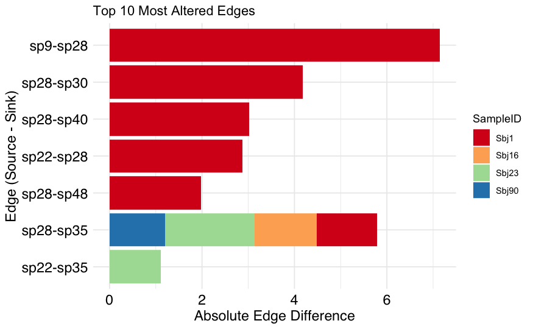

```r
# Filter to top 10 changed edges
top_edges <- Combined_data_sortededge %>% slice_head(n = 10)

# Plot
ggplot(top_edges, aes(x = reorder(paste(Source, Sink, sep="-"), abs(Edge_diff)),
                      y = abs(Edge_diff), fill = SampleID)) +
  geom_col() +
  coord_flip() +
  scale_fill_brewer(palette = "Spectral") +
  labs(x = "Edge (Source - Sink)", y = "Absolute Edge Difference",
       title = "Top 10 Most Altered Edges") +
  theme_minimal() +
  theme(axis.text.x = element_text(family = "sans", color = "black", size = 14),
        axis.text.y = element_text(family = "sans", color = "black", size = 14),
        axis.title.x = element_text(family = "sans", color = "black", size = 14),
        axis.title.y = element_text(family = "sans", color = "black", size = 14))
```

Save the data

```r
saveRDS(Dataset2g_Res, here("Output", "SE_Lionness", "Dataset2g_Res_100sbj.rds"))

write.csv(Combined_data_sortededge, here("Output", "SE_Lionness", "Edges_100sbj.csv"))
```